# Beta Diversity

```r
library(tidyverse)
library(vegan)
set.seed(12345)
```

PERMANOVA and NMDS of rarefied table.

```r
data <- read_csv("table.from_biom_after_rare.csv")
metadata <- read_csv("enrichment_metadata.csv")
```

We need to invert the dataframe so that each row is a sample and each column is an ASV. This is also an opprotunity to filter out any samples/treatments we are not interested in.

```r
flip <- data %>%
 # select(1, !contains("_P1_"))  %>% # if you want to filter out certain samples could be done here
  pivot_longer(2:16, names_to = "Sample", values_to = "count") %>%
  pivot_wider(names_from = "ASV ID", values_from = count)
```

Make sure that the dataframe and metadata have the same number of rows and that the rows are in the exact same order.

```r
meta <- flip %>%
  select(1) %>%
  inner_join(metadata)
```

Here we filter the dataframe to remove the first column composed of sample names.

```r
table <- flip %>%
  select(2:2743)
```

The next step is to take the data frame and turn it into a distance matrix. Here we are calculating distance using Bray-Curtis distance, but many other methods are available. Distance matrices are pairwise comparisons that compare the similarity of every community on a scale from 0 to 1. 0 indicates communities are exactly the same and 1 indicates there is no similarity in the communities.

```r
data.t <- as.matrix(vegdist(table, method = 'bray'))
```

PERMANOVA (Permutational multivariate analysis of variance) is a non-parametric multivariate statisitical test that is useful when studying microbial communities because it allows you to compare how similar different communities are. PERMANOVA is useful because it has very few assumptions that the data need to meet (allows for differences in variation between groups, insensitive to multicollinearity, datasets can be zero-inflated).

Interpreting the output: F-ratio: Compares total sum of squared dissimilarities of objects from different groups to objects in the same group, also called the effect size. Larger F-ratios mean greater separation between groups R2: Is a statistic the shows the percentage of variance explained by each variable  
P: If p<0.05 differences between groups are unlikley to have occurred by chance

```r
mer_perm<-adonis2(data.t ~ Treatment*RME, data=meta, permutations = 999)
mer_perm
```

```
Permutation test for adonis under reduced model
Terms added sequentially (first to last)
Permutation: free
Number of permutations: 999

adonis2(formula = data.t ~ Treatment * RME, data = meta, permutations = 999)
              Df SumOfSqs      R2      F Pr(>F)
Treatment      3   0.7431 0.15021 0.7818  0.735
RME            4   3.0227 0.61099 2.3851  0.023 *
Treatment:RME  5   0.5477 0.11071 0.3458  1.000
Residual       2   0.6337 0.12808
Total         14   4.9472 1.00000
---
Signif. codes:  0 ‘***’ 0.001 ‘**’ 0.01 ‘*’ 0.05 ‘.’ 0.1 ‘ ’ 1
```

We can do pairwise comparisons to understand which sites are different from each other

```r
library(pairwiseAdonis)
pairwise.adonis<-pairwise.adonis2(data.t ~ RME, data=meta, permutations = 999)
```

[output not shown]

```r
pairwise.adonis
```

```
$parent_call
[1] "data.t ~ RME , strata = Null , permutations 999"

$none_vs_normal_high
         Df SumOfSqs      R2      F Pr(>F)
RME       1 0.010076 0.75066 6.0211   0.25
Residual  2 0.003347 0.24934
Total     3 0.013423 1.00000

$none_vs_normal_low
         Df  SumOfSqs      R2      F Pr(>F)
RME       1 0.0083798 0.94606 17.538 0.3333
Residual  1 0.0004778 0.05394
Total     2 0.0088577 1.00000

$none_vs_High
         Df SumOfSqs      R2      F Pr(>F)
RME       1 0.018391 0.30811 2.2265  0.145
Residual  5 0.041299 0.69189
Total     6 0.059690 1.00000

$none_vs_Low
         Df  SumOfSqs      R2      F Pr(>F)
RME       1 0.0267967 0.87656 14.202   0.25
Residual  2 0.0037736 0.12344
Total     3 0.0305703 1.00000

$normal_high_vs_normal_low
         Df  SumOfSqs      R2      F Pr(>F)
RME       1 0.0111115 0.74392 8.7153    0.1
Residual  3 0.0038248 0.25608
Total     4 0.0149364 1.00000

$normal_high_vs_High
         Df SumOfSqs      R2      F Pr(>F)
RME       1 0.080772 0.64402 12.664  0.013 *
Residual  7 0.044646 0.35598
Total     8 0.125419 1.00000
---
Signif. codes:  0 ‘***’ 0.001 ‘**’ 0.01 ‘*’ 0.05 ‘.’ 0.1 ‘ ’ 1
```

[output cut: 16 more lines]

```
         Df SumOfSqs      R2      F Pr(>F)
RME       1 0.067544 0.94078 47.662    0.1
Residual  3 0.004251 0.05922
Total     4 0.071796 1.00000

$High_vs_Low
         Df SumOfSqs      R2      F Pr(>F)
RME       1 0.020255 0.31005 3.1457  0.022 *
Residual  7 0.045073 0.68995
Total     8 0.065328 1.00000
---
Signif. codes:  0 ‘***’ 0.001 ‘**’ 0.01 ‘*’ 0.05 ‘.’ 0.1 ‘ ’ 1

attr(,"class")
[1] "pwadstrata" "list"
```

Now we can visualize community similarity using NMDS (non-metric multidimensional scaling), an iterative and non-parametirc method which aims to plot pairwise dissimilarity between communities. Each point will represent once sample (or microbial community). The closer points are together the more similar those communities are to each other.

How good an NMDS visualization is at representing your community can be assessed by the stress values. Typically NMDS with stress below 0.2 can be retained. Stress value below 0.05 is considered a great fit Stress value below 0.1 is considered a good fit Stress value below 0.2 is considered an ok fit A stress value above 0.2 is questionable and anything approaching 0.3 is considered arbitrary

Importatant parameters in the metaMDS function: “trymax”” is the maximum number of random starts it will perform to try to reach convergence. The defaul value is 20 and if it reaches convergence after 20 random starts it will end there. Otherwise it will go either until it reaches convergence or the number of tries youhave put in.

```r
NMDS<-metaMDS(data.t, trymax= 200)
```

```
*** Best solution repeated 1 times
```

```r
MDS1 = NMDS$points[,1]
MDS2 = NMDS$points[,2]
NMDS = data.frame(NMDS1 = MDS1, NMDS2 = MDS2)
```

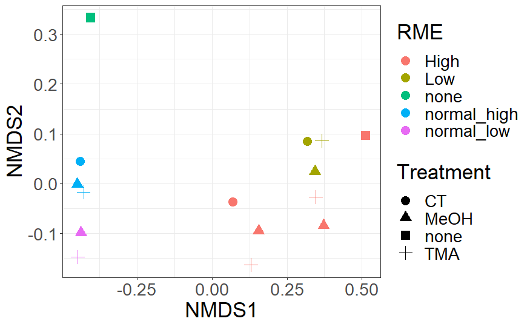

```r
NMDS_plot <- ggplot(NMDS) +
  geom_point(aes(x=NMDS1, y=NMDS2, col=meta$RME,  shape=meta$Treatment), size=4) +
  theme_bw() +
  labs(color = "RME", shape= "Treatment")+
   #scale_shape_manual(values = c(2, 15, 3)) +  #change shape of points
  #stat_ellipse(aes(x=NMDS1, y=NMDS2, col=meta_raw$Site)) + #add ellipse around variables
  #scale_color_manual(values=c('#1b9e77','#d95f02','#7570b3', '#e7298a', '#66a61e', '#e6ab02'))+ #change color of points
   theme(text=element_text(size=21))
 NMDS_plot
```

PERMANOVA and NMDS of rarefaction table.

```r
raw <- read_csv("october_data/asv_table_16S_gtdb_raw.csv")
metadata <- read_csv("october_data/metadata_r.csv")
```

Here we need to invert the table as we did above but also need to sample out all samples that are below 15000 reads. Samples above 15000 will retain all reads in this step.

```r
flip_raw <- raw %>%
  pivot_longer(2:60, names_to = "Sample", values_to = "count") %>%
  group_by(Sample) %>%
  mutate(total = sum(count)) %>%
  filter(total > 15000) %>%
  select(-total) %>%
  pivot_wider(names_from = ASV, values_from = count) %>%
  ungroup()
```

Match metadata and sample table

```r
meta_raw <- flip_raw %>%
  select(1) %>%
  inner_join(metadata)
```

```r
flip_raw2 <- flip_raw %>%
  select(2:19500)
```

Here we will rarefy to 15,000 reads, avedist is simlar to vegdist except it will subsample 100 times and take the average of every subsample. This helps to incorporate all the data such as rare taxa that may otherwise be lost with a single subsample.

```r
data.raw <- as.matrix(avgdist(flip_raw2, dmethod="bray", sample=15000))
```

```r
perm_rare<-adonis2(data.raw ~ Site*Depth, data=meta_raw, permutations = 999)
perm_rare
```

[output not shown]

```r
NMDS<-metaMDS(data.raw, trymax= 200)
MDS1 = NMDS$points[,1]
MDS2 = NMDS$points[,2]
NMDS = data.frame(NMDS1 = MDS1, NMDS2 = MDS2)
```

```r
NMDS_raw <- ggplot(NMDS) +
  geom_point(aes(x=NMDS1, y=NMDS2, col=meta_raw$Site,  shape=meta_raw$Depth), size=4) +
  theme_bw() +
  labs(color = "Site", shape= "Depth")+
  #scale_shape_manual(values = c(2, 15, 3)) +  #change shape of points
  #stat_ellipse(aes(x=NMDS1, y=NMDS2, col=meta_raw$Site)) + #add ellipse around variables
  #scale_color_manual(values=c('#1b9e77','#d95f02','#7570b3', '#e7298a', '#66a61e', '#e6ab02'))+ #change color of points
   theme(text=element_text(size=21))
 NMDS_raw
```

[output not shown]

BETADISPERSION Betadispersion tests for multivariate homogeneity between groups or varainces between groups. This helps understand if there is greater variabilty in one group compared to another. Betadispersion paried with PERMANOVA helps to understand if the diferences observed are a result of differences in community strucutre or differences between variance in the communities within each treatment.

```r
data.p <- vegdist(table , method = 'bray')
b=betadisper(d=data.p, group=meta$Site) # calculate multivariate dispersion
anova(b) #perfporm anova to determine if dispersion is different between site
permutest(b, pairwise = TRUE, permutations = 999)
(mod.HSD <- TukeyHSD(b))
plot(mod.HSD)
boxplot(b)
```

[output not shown]